# Scaling data science with Airflow and Kubernetes

[figure not shown]

## javier.asensio@octoenergy.com

## Igor Gotlibovich | David Sykes | Octopus Energy Data Team

## Traditional energy grid

[figure not shown]

## Smart(er) energy grid

[figure not shown]

# Our team

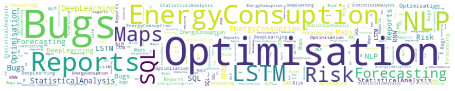

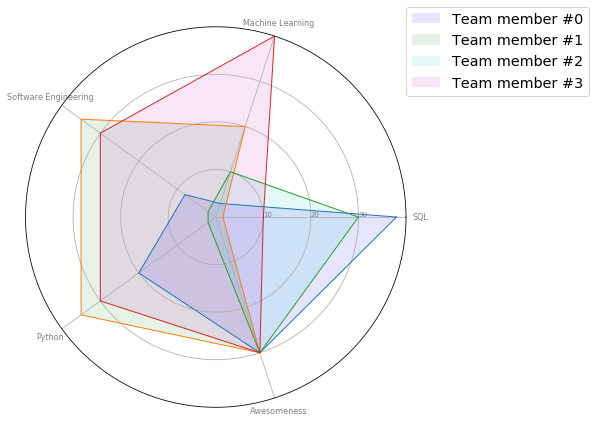

## More data every day...

[figure not shown]

# Problem statement

*How to support growth (technically) with a heterogenous backlog, technologies, and team?*

- Give support to different type of processes: ETL, DL libraries, intensive CPU tasks...
- Different implementation approaches: python scripts, report generation, notebooks...
- Encouraging testability and repeatability.

# Airflow

# Airflow as central point of DS processes

*Airflow is a platform to programmatically author, schedule and monitor workflows.* airflow.apache.org

- Glorified crontab.
- But has a (niceish) UI.
- Workflows are defined as DAGs (directed acyclic graphs of tasks) in pure python.

(Other alternatives lugi, argo, pure crontab, etc)

[figure not shown]

# Airflow features

- Web UI
- Scheduler (with backfilling).
- XCOM (tasks can communicate amongst them).
- Already made hooks to get data from different sources.
- Tons of plug-ins.
- Allows to define your ETL logic in python along with the configuration of the DAG.

# Airflow features (that we actually use)

- Web UI
- Scheduler (with backfilling).
- XCOM (tasks can communicate amongst them). **Adds unnesary complexity to the system.**
- Already made hooks to get data from different sources. **Credentials are available to everone**
- Tons of plug-ins. **Everyone needs to be an Airflow expert**
- Allows to define your ETL logic in python along with the configuration of the DAG. **don't get me started**

I'll do it anyways:

- Testing incredibly difficult.
- Difficult maintainance: procedural definition tangled with complex logic.
- Dependecies are shared among all the dags. (2Gb of spacy models in your system to just multiply two matrices...)
- Using different hardware becomes painful (CUDA 👀)

# Move everything out airflow

- Pure python scripts that are enforced to follow a simple layered architecure.
  - Command line interface
  - Data loading layer
  - Transformation layer <- easy testing
  - Data storing layer
- Better testing and usable outside of airflow.
- Dockerise (containarise is a mouthful) the script.
  - Only the needed dependencies are installed.
  - Different versions can be used by different scripts.
- Run it from airflow (*KubernetesPodOperator*)

# Kubernetes

Kubernetes is an open-source system for automating deployment, scaling, and management of containerized applications. kubernetes.io

- Run our processes from the docker images (aka pods).
- Supports different types of hardware assigning the right pod to the right hardware (GPU, CPU, other resources, etc).
- Huge abstraction layer for cluster maintainace, secrets management, and resource management.
- Easy monitoring of tasks and memory usage.
- Active community.
- Supports your favourite cloud provider.

# Kubernetes (the downsides)

- Steep learning curve
- Thought for microservices rather than one-off tasks.

# Final architecure

[figure not shown]

# Let's build a small replica!

- We'll use minikube
- The instructions can be found at github.com/capitancambio/kubernetes-talk
- ☝️ and all the necessary code

# Jaye says: Let's do this

[figure not shown]

# What we are going to build

- Aiflow server with a postgres database.
- Sidecar container to automatically pull dag updates from a git repo.
- SFTP server to pull data from and store the results.

# Thanks!

[figure not shown]

## javier.asensio@octoenergy.com

## share.octopus.energy/mist-rain-538

```python
questions = raw_input('questions?')
```

```
---------------------------------------------------------------------------
NameError                                 Traceback (most recent call last)
<ipython-input-8-cea47b018aef> in <module>
----> 1 questions = raw_input('questions?')

NameError: name 'raw_input' is not defined
```